# Proyecto 2

**Integrantes:**

Luciana Figueroa Valdivia (20120673), Chiara Zamora Mendoza (20160565), Yoseph Ayala Valencia (20163047), Claudia Villena Tagle (20150197)

```r
#loading libraries
library(ISLR2)
library(glmnet)
library(MASS)
library(boot)
library(tidyverse)
```

```r
library(tibble)
library(ggplot2)
```

**1)**

1. Considere el índice de Gini, el error de clasificación y la entropía en un árbol de clasificación con dos clases. Cree una sola gráfica que muestre cada una de estas cantidades como una función de pˆm1. El eje x debe mostrar pˆm1, con un rango de 0 a 1, y el eje y debe mostrar el valor del índice de Gini, el error de clasificación y la entropía.
- *Índice de Gini*

$$G=\sum_{k=1}^K\hat p_{mk}(1 - \hat p_{mk})$$

- *Entropía*

$$D=-\sum_{k=1}^K\hat p_{mk}\text{log} \hat p_{mk}$$

```r
p = seq(0, 1, 0.01)

indice_gini = 2 * p * (1 - p)

error_clasificacion = 1 - pmax(p, 1 - p)

entropia = - (p * log(p) + (1 - p) * log(1 - p))
```

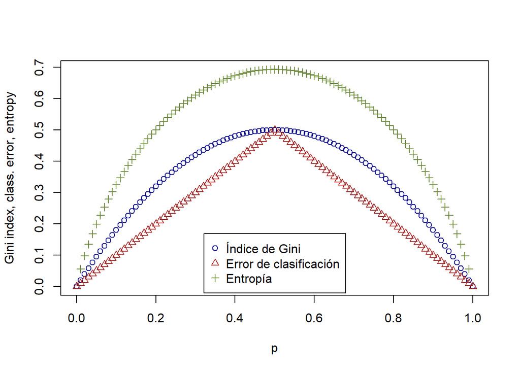

```r
matplot(p,
        cbind(indice_gini, error_clasificacion, entropia),
        pch = c(1,2,3),
        col = c("darkblue", "brown", "darkolivegreen4"),
        ylab = "Gini index, class. error, entropy",
        type = 'b')
legend('bottom', inset=.01, legend = c('Índice de Gini', 'Error de clasificación', 'Entropía'),
       col = c("darkblue", "brown", "darkolivegreen4" ),
       pch=c(1,2,3))
```

**2)**

**Enfoque del voto mayoritario**

Consideraremos como punto de corte al 0.5. Es decir, si es que hay más cantidad de valores que sean mayor o igual a 0.5, ello significa que el voto mayoritario indica que la predicción nos da rojo. Si es que es menor a 0.5, la predicción nos da verde. Encontramos que 6 valores son mayores o iguales a nuestro punto de corte (0.5) y que 4 son menores. De esta forma, 6 > 4 lo que implica que, bajo este enfoque, la predicción nos debe dar rojo.

**Enfoque de probabilidad media**

Para este enfoque, solo debemos promediar los valores. Realizando ello, obtenemos un valor de 0.45. Al ser este menor que nuestro punto de corte (0.5), nos indicaría que la predicción es verde bajo este enfoque.

```r
#creamos el vector con el conjunto de valores
r <-  c(0.1, 0.15, 0.2, 0.2, 0.55, 0.6, 0.6, 0.65, 0.7, 0.75)

#Enfoque del voto mayoritario
R <- sum(r >= 0.5)
R
```

```
## [1] 6
```

```r
G <- sum(r < 0.5)
G
```

```
## [1] 4
```

```r
R > G #TRUE
```

```
## [1] TRUE
```

```r
#Enfoque de probabilidad media
mean(r) #0.45
```

```
## [1] 0.45
```

**3)** Para el caso de los árboles de decisión tenemos dos posibilidades, los de clasificación y los de regresión. En el caso de clasificación usamos el índice de gini o el de entropía como criterio de decisión para las particiones óptimas que se harán en el árbol.  
En el caso de los arboles de regresión, que es en el cual nos concentraremos, se usa mínimos cuadrados. Buscamos las particiones que reduzcan la suma de cuadrados de los residuos, o en inglés *Residual Sum Square (RSS)*, entre la observación y la media de cada nodo encontrado. Dado el número de variables que normalmente se usan para este algoritmo, es casi imposible tomar en cuenta todas las particiones que se pueden armar, por eso se hace uso de un método de partición recursivo, denominado en inglés como *recursive binary splitting*.  
Lo que hace este método es comenzar desde el tope del árbol y selecciona la variable que dividirá a la base en dos grupos, la variable seleccionada será aquella que reduzca el *RSS*; Luego de encontrar la variable ideal y tener dos niveles nuevos, pasa a abrir estos dos nodos hallados y volver a dividirlos en dos a cada uno, hallando una nueva variable que siga minimizando el *RSS*. Lo importante de este método es que es recursivo ya que va a intentar todas las variables posibles en el *mismo* nivel, es decir, no pasará a la siguiente apertura de los nodos si es que no está seguro de haber encontrado a variable adecuada para la partición.  
Este proceso se repetirá hasta que quede un número mínimo de observaciones dentro de los nodos finales.  
Al tener el árbol final tenemos que tomar en cuenta que se puede presentar el problema de sobreajuste. Dada a la cantidad de variables y sub conjuntos de árboles que se pueden obtener dentro del árbol obtenido por el método de *recursive binary splitting*, es muy costoso hacer validación cruzada, es por eso que el paso final es hacer un podado del árbol, denominado en inglés como *pruning*, que introduce un parámetro $\alpha$ que permite que se encuentre los mejores subsets de árboles que obtienen el mejor ajuste de la data de entrenamiento con la menor cantidad de niveles posibles. Para hallar esto, se busca reducir la ecuación de:

$$\sum_{m=i}^{|T|}\sum_{i:x_i \in R_m} (y_i - \hat{y}_{R_m})^2 + \alpha|T|$$

En este caso, $|T|$ es el número de nodos terminales del arbol $T$, considerando que si $\alpha$ = 0 tendríamos el árbol obtenido originalmente, a medida que aumente $\alpha$ el árbol se “podará” más. El $R_m$ es la partición correspondiente al nodo terminal $m$ y el $\hat{y}_{R_m}$ es la media de las observaciones del set de entrenamiento que se encuentran en la partición $R_m$.  
Para obtener el $\alpha$ ideal, haremos una validación de k-fólios y al obtener este, volvemos al dataset completo para obtener el árbol podado correspondiente a este $\alpha$ ideal.

**4)**

Si bien en las indicaciones se nos pide que mtry estén entre el rango de 5 a 40 con saltos de 5, solo hemos considerado los casos cuando mtry es 5 y 10. Cuando mtry es mayor o igual 15, R nos indica lo siguiente: “invalid mtry: reset to within valid range”. Esto quiere decir que, cuando tomamos estos valores, R nos indica que no son válidos. Por tanto, lo que hace el software es colocar a mtry con el valor por defecto. Dado que no es de interés del ejercicios utilizar el valor de mtry por defecto, solo estamos considerando los valores válidos para mtry: 5 y 10.

```r
library(randomForest)
## training and testing data
set.seed (1)

train <- sample (1: nrow(Boston), nrow(Boston) / 2)

boston.test <- Boston[-train, "medv"]

## lists

#usamos solo los valores de 5 y 10 para mtry. Esto debido a que, cuando se usan valores desde 15 en adelante, R bota el siguiente error: "invalid mtry: reset to within valid range"

mtry_list <- as.list( seq(5, 10, by = 5) )

ntree_list <- as.list( seq(200, 800, by = 100) )

df = expand.grid(mtry_list, ntree_list)

## number of possible combinations
n_combinations <- nrow( expand.grid(mtry_list, ntree_list) )

## MSE vector
MSE_vector <- rep(0, n_combinations)


## Loop que combina mtry = (5,10) con ntree = (200,300,400,500,600,700,800)

for(i in seq_len(nrow(df))) {


  bag.boston <- randomForest(medv ∼ ., data = Boston ,
                           subset = train ,
                           mtry = unlist( df[i,][1]  ),
                           ntree = unlist( df[i,][2]  ))


  yhat.bag <- predict(bag.boston , newdata = Boston[-train , ])

  MSE_vector[i] <- mean (( yhat.bag - boston.test)^2)


}

MSE_vector
```

```
##  [1] 18.99476 22.84642 18.51169 22.42257 18.93116 21.67159 18.58548 21.44052
##  [9] 19.12999 22.17471 19.03881 21.67164 19.06835 21.92660
```

[figure not shown]

```r
mtry_mtree <- c("(5,200)","(5,300)","(5,400)","(5,500)","(5,600)","(5,700)","(5,800)",
            "(10,200)","(10,300)","(10,400)","(10,500)","(10,600)","(10,700)","(10,800)")

error_prueba <- MSE_vector

MSE_df = data.frame(mtry_mtree, error_prueba )

MSE_df = rownames_to_column(MSE_df)


ggplot(MSE_df,
       aes(x=mtry_mtree, y=error_prueba)) +
  geom_bar(stat="identity") +
  theme(axis.text.x=element_text(angle=-90, vjust=0.5, hjust=0))
```

Si ejecuta el siguiente code chunck, podrá visualizar el error/warning que ocurre cuando mtry está entre el rango de 5 a 40 con saltos de 5

```r
mtry_list <- as.list( seq(5,40, by = 5) )

ntree_list <- as.list( seq(200, 800, by = 100) )

df = expand.grid(mtry_list, ntree_list)

## number of possible combinations
n_combinations <- nrow( expand.grid(mtry_list, ntree_list) )

## MSE vector
MSE_vector <- rep(0, n_combinations)


for(i in seq_len(nrow(df))) {


  bag.boston <- randomForest(medv ∼ ., data = Boston ,
                           subset = train ,
                           mtry = unlist( df[i,][1]  ),
                           ntree = unlist( df[i,][2]  ))


  yhat.bag <- predict(bag.boston , newdata = Boston[-train , ])

  MSE_vector[i] <- mean (( yhat.bag - boston.test)^2)


}
```

[output not shown]

[output cut: 70 more lines]

[output not shown]

**5) Objetivo: buscaremos predecir las ventas de asientos de automóvil, de manera cuantitativa**

1. Divida el conjunto de datos en un conjunto de entrenamiento y un conjunto de prueba.

```r
set.seed (1)
train = sample (1: nrow(Carseats), nrow(Carseats) / 2)
test = (1:nrow(Carseats))[-train]
```

```r
train
```

```
##   [1] 324 167 129 299 270 187 307  85 277 362 330 263 329  79 213  37 105 217
##  [19] 366 165 290 391  89 289 340 326 390  42 111  20  44 343  70 121  40 172
##  [37]  25 248 198  39 298 280 160  14 130  45  22 206 230 193 104 375 255 349
##  [55] 350 103 331  13 296 383 176 279 110  84  29 141 252 221 108 304  33 355
##  [73] 149 287 102 145 118 344 107  64 224 345 316  51 333 380 138 398 397 282
##  [91] 143 285 170  48 204 295  24 181 214 342 225 163  43   1 336  78 284 116
## [109] 233  61  86 338  49 242 246 247 239 219 135 372 371 317  53 356  65 384
## [127] 124  77 218  98 194  19  31 174 237  75  16 382  92 122 152 314 207 249
## [145] 358 229 399 223 381 318 140 126 357 352 293 264  15 392 276 195 201 347
## [163]  17 212 127 133  41 283 332 159 117  72  36 288 234 157 386 321 313 278
## [181] 266 106 185  88 309 251 302 294  50  80  30  93 243 348 257 305 164 168
## [199] 334 258
```

```r
test
```

```
##   [1]   2   3   4   5   6   7   8   9  10  11  12  18  21  23  26  27  28  32
##  [19]  34  35  38  46  47  52  54  55  56  57  58  59  60  62  63  66  67  68
##  [37]  69  71  73  74  76  81  82  83  87  90  91  94  95  96  97  99 100 101
##  [55] 109 112 113 114 115 119 120 123 125 128 131 132 134 136 137 139 142 144
##  [73] 146 147 148 150 151 153 154 155 156 158 161 162 166 169 171 173 175 177
##  [91] 178 179 180 182 183 184 186 188 189 190 191 192 196 197 199 200 202 203
## [109] 205 208 209 210 211 215 216 220 222 226 227 228 231 232 235 236 238 240
## [127] 241 244 245 250 253 254 256 259 260 261 262 265 267 268 269 271 272 273
## [145] 274 275 281 286 291 292 297 300 301 303 306 308 310 311 312 315 319 320
## [163] 322 323 325 327 328 335 337 339 341 346 351 353 354 359 360 361 363 364
## [181] 365 367 368 369 370 373 374 376 377 378 379 385 387 388 389 393 394 395
## [199] 396 400
```

2. Ajuste un arbol de regresion al conjunto de entrenamiento. Interprete los resultados. ¿Que valor de MSE obtienes para el conjunto de prueba?

```r
tree.Carseats = tree(Sales ∼., Carseats , subset = train)
tree.Carseats.sum = summary(tree.Carseats)
tree.Carseats.sum
```

```
##
## Regression tree:
## tree(formula = Sales ~ ., data = Carseats, subset = train)
## Variables actually used in tree construction:
## [1] "ShelveLoc"   "Price"       "Age"         "Advertising" "CompPrice"
## [6] "US"
## Number of terminal nodes:  18
## Residual mean deviance:  2.167 = 394.3 / 182
## Distribution of residuals:
##     Min.  1st Qu.   Median     Mean  3rd Qu.     Max.
## -3.88200 -0.88200 -0.08712  0.00000  0.89590  4.09900
```

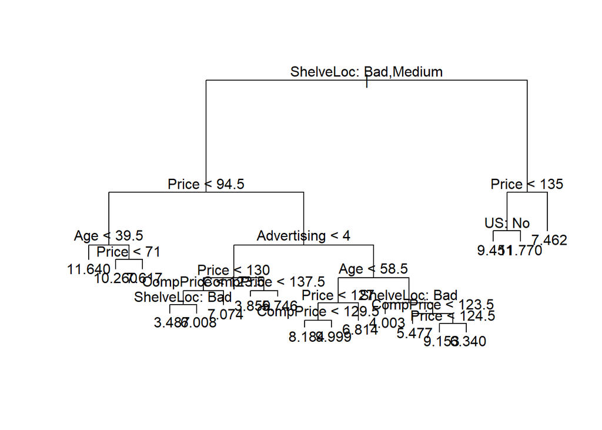

```r
#Observamos el grafico:
plot(tree.Carseats)
text(tree.Carseats , pretty = 0)
```

Respuesta: En este caso, solo se emplearon 6 variables para construir el arbol. Estas variables son la calidad de la ubicación de las estanterías (Shelveloc),el precio de los asientos en cada lugar (Price), la edad de la población (Age) , el presupuesto de publicidad local (Advertising), el precio cobrado por el competidor en cada ubicación (Comprice) y la variable US que indica si la tienda se ubica en USA o no.

```r
used_vars <- as.character(tree.Carseats.sum$used)
used_vars
```

```
## [1] "ShelveLoc"   "Price"       "Age"         "Advertising" "CompPrice"
## [6] "US"
```

Además,se tienen 18 nodos terminales en el árbol.

```r
Carseats.test = predict( tree.Carseats, newdata=Carseats[test,] )
test.MSE = mean( ( Carseats.test - Carseats[test,]$Sales )^2 )
print( test.MSE )
```

```
## [1] 4.922039
```

3. Utilice la validacion cruzada para determinar el nivel optimo de complejidad del arbol. ¿Podra el arbol mejorar el MSE del conjunto de prueba?

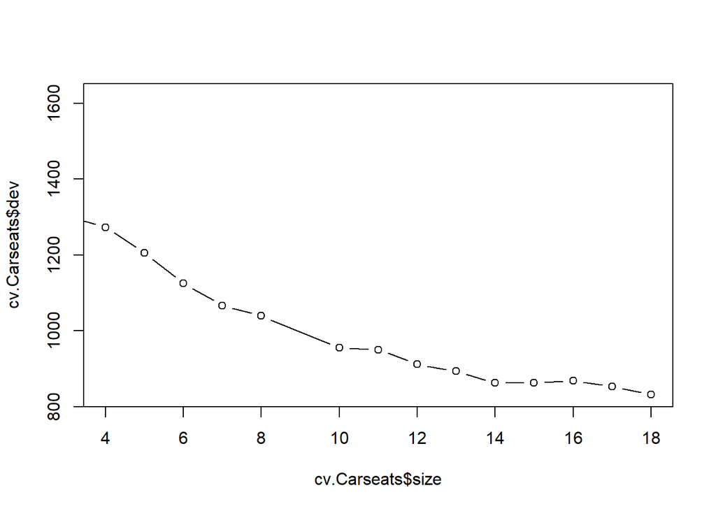

```r
cv.Carseats <- cv.tree(tree.Carseats)
plot(cv.Carseats$size, cv.Carseats$dev, type = "b", xlim = c(4, 18))
```

Seleccionamos el mejor nivel de complejidad del arbol. Ahora empleamos ese nivel de nodos para el árbol:

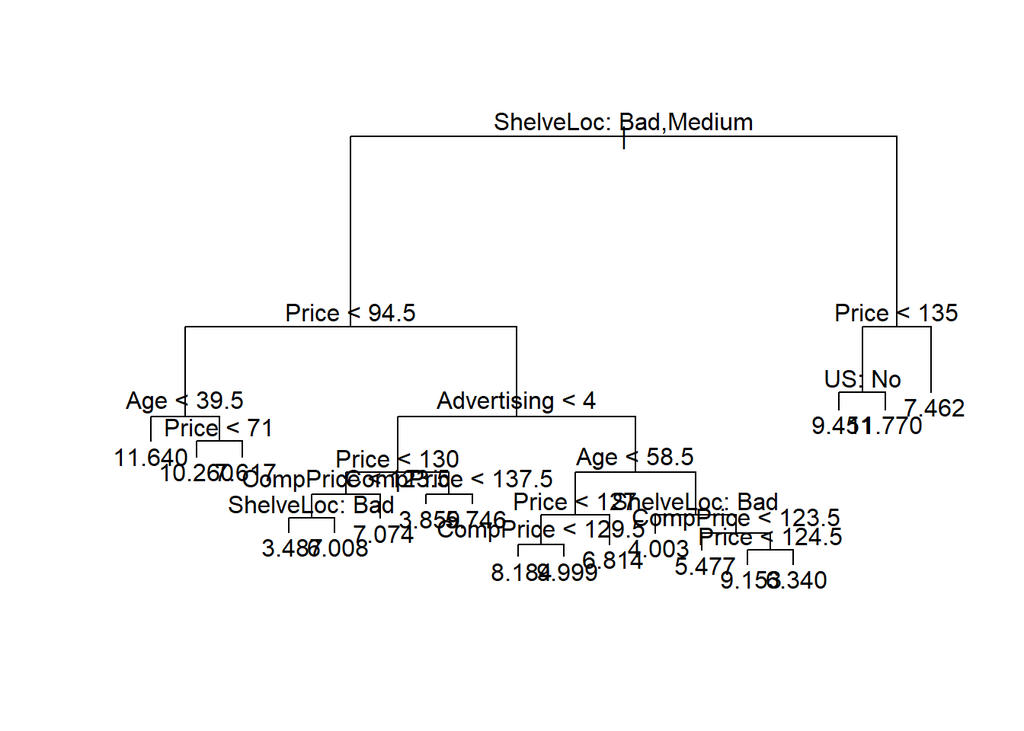

```r
prune.Carseats <- prune.tree(tree.Carseats , best = 18)
plot(prune.Carseats)
text(prune.Carseats , pretty = 0)
```

Respuesta: El tamaño óptimo será de 18 nodos terminales

Al probar el modelo en la data de prueba, se observa que el MSE asociado al árbol de decisión se mantienen en: 4.922039

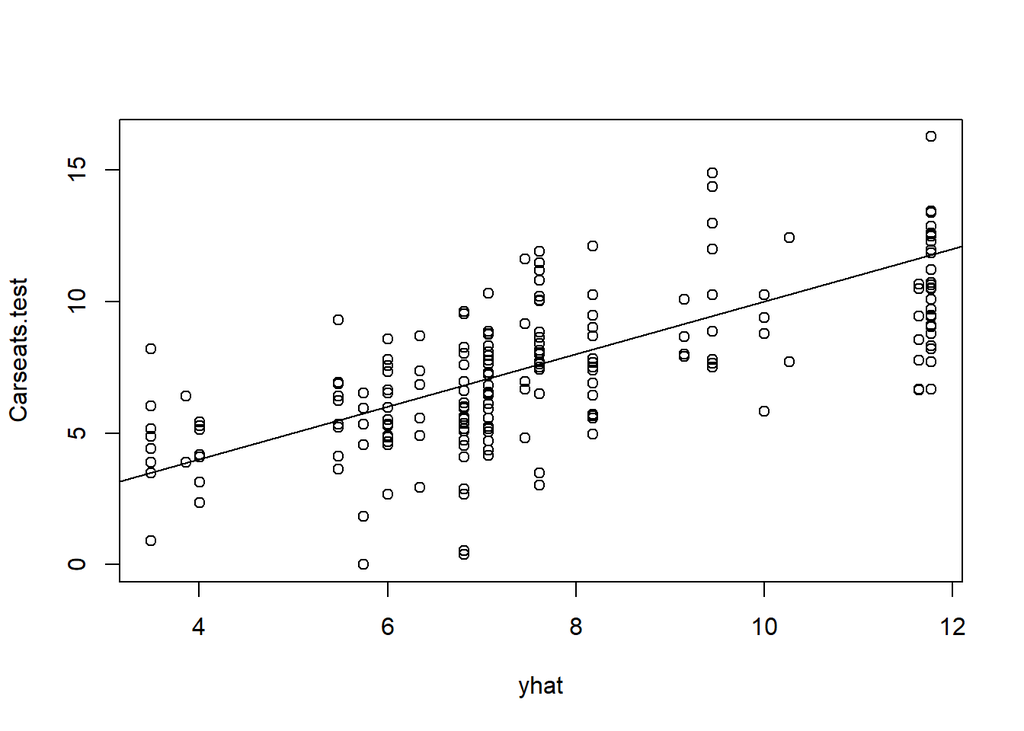

```r
yhat <- predict(tree.Carseats , newdata = Carseats[-train , ])
Carseats.test <- Carseats[-train, "Sales"]
plot(yhat , Carseats.test)
abline (0, 1)
```

```r
mean (( yhat - Carseats.test)^2)
```

```
## [1] 4.922039
```

4. Utilice el metodo bagging para analizar estos datos. ¿Que valor de MSE obtienes para el conjunto de prueba? Use la funcion importance() para determinar que variables son las mas importantes.

```r
dim(Carseats)
```

```
## [1] 400  11
```

```r
#install.packages( "randomForest" )
set.seed (1)
library(randomForest)
bag.Carseats <- randomForest(Sales ∼ ., data = Carseats, subset = train , mtry = 11, importance = TRUE)
summary(bag.Carseats)
```

```
##                 Length Class  Mode
## call              6    -none- call
## type              1    -none- character
## predicted       200    -none- numeric
## mse             500    -none- numeric
## rsq             500    -none- numeric
## oob.times       200    -none- numeric
## importance       20    -none- numeric
## importanceSD     10    -none- numeric
## localImportance   0    -none- NULL
## proximity         0    -none- NULL
## ntree             1    -none- numeric
## mtry              1    -none- numeric
## forest           11    -none- list
## coefs             0    -none- NULL
## y               200    -none- numeric
## test              0    -none- NULL
## inbag             0    -none- NULL
## terms             3    terms  call
```

Evaluamos el performance del modelo:

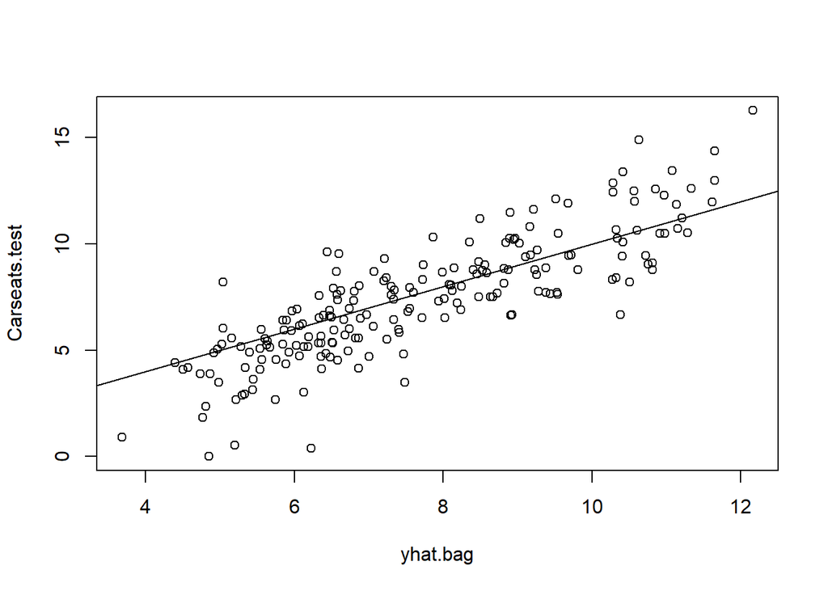

```r
Carseats.test <- Carseats[-train, "Sales"]

yhat.bag <- predict(bag.Carseats , newdata = Carseats[-train , ])
plot(yhat.bag , Carseats.test)
abline (0, 1)
```

```r
mean (( yhat.bag - Carseats.test)^2)
```

```
## [1] 2.605253
```

Identificamos la importancia de los predictores del modelo generado:

```r
importance.bag = importance( bag.Carseats )
print( importance.bag[ order( importance.bag[,1] ), ] )
```

```
##                %IncMSE IncNodePurity
## Population  -1.8074075     58.244596
## Urban        0.1728373      9.822082
## Education    0.5962186     44.598731
## US           4.2172102     18.073863
## Income       4.7121131     91.264880
## Advertising 12.7692401     97.164338
## Age         17.7275460    157.846774
## CompPrice   24.8888481    170.182937
## ShelveLoc   48.8886689    380.032715
## Price       56.3326252    502.903407
```

Respuesta: Se observa que el MSE asociado a este arbol es de 2.605253

```r
importance.bag
```

```
##                %IncMSE IncNodePurity
## CompPrice   24.8888481    170.182937
## Income       4.7121131     91.264880
## Advertising 12.7692401     97.164338
## Population  -1.8074075     58.244596
## Price       56.3326252    502.903407
## ShelveLoc   48.8886689    380.032715
## Age         17.7275460    157.846774
## Education    0.5962186     44.598731
## Urban        0.1728373      9.822082
## US           4.2172102     18.073863
```

5. Utilice Random forest para analizar estos datos. ¿Que valor de MSE obtienes para el conjunto de prueba? Use la funcion importance() para determinar que variables son las mas importantes.Describa el efecto de m, el numero de variables consideradas en cada division, sobre la tasa de error obtenida.

Sabemos que por default randomForest() emplea p/3 variables. En este ejercicio se emplearán mtry = 3, donde m= √p.

```r
set.seed (1)
rf.Carseats <- randomForest(Sales ∼ ., data = Carseats ,
                          subset = train , mtry = 3, importance = TRUE)
yhat.rf <- predict(rf.Carseats, newdata = Carseats[-train , ])
mean (( yhat.rf - Carseats.test)^2)
```

```
## [1] 2.960559
```

Observamos que con m = 3, tenemos un Test MSE de 2.960559

Vemos la importancia de las variables:

```r
importance.ran = importance(rf.Carseats)
importance.ran
```

```
##                %IncMSE IncNodePurity
## CompPrice   14.8840765     158.82956
## Income       4.3293950     125.64850
## Advertising  8.2215192     107.51700
## Population  -0.9488134      97.06024
## Price       34.9793386     385.93142
## ShelveLoc   34.9248499     298.54210
## Age         14.3055912     178.42061
## Education    1.3117842      70.49202
## Urban       -1.2680807      17.39986
## US           6.1139696      33.98963
```

A su vez, al medir la importancia de las variables mediente el aumento del %IncMSE, resaltan: Price, Shelveloc, CompPrice. Es decir, al quitar a estas variables, el MSE del modelo aumenta. En el caso de la variable Price, el MSE aumenta en un 34.97%. Esto se observa en el siguiente gráfico:

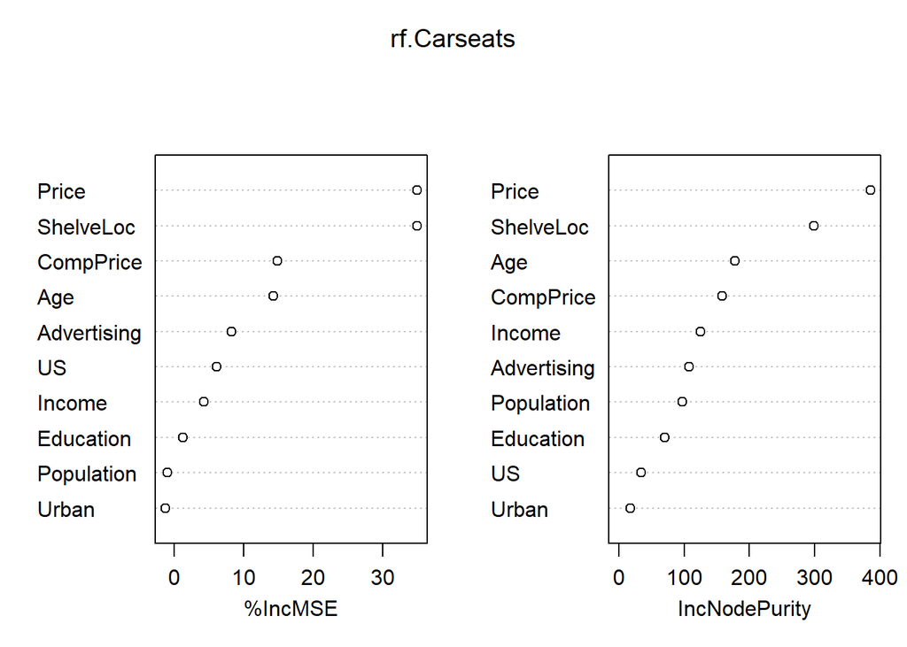

```r
varImpPlot(rf.Carseats)
```

A su vez, para medir el efecto de m, el numero de variables consideradas en cada division, sobre la tasa de error obtenida, se plantea:

Aumentar el número de variables para identificar su efecto en la tasa de error obtenida:

1. Primero trabajamos con 6 variables:

```r
set.seed (1)
rf.Carseats <- randomForest(Sales ∼ ., data = Carseats ,
                          subset = train , mtry = 6, importance = TRUE)
yhat.rf <- predict(rf.Carseats, newdata = Carseats[-train , ])
mean (( yhat.rf - Carseats.test)^2)
```

```
## [1] 2.667767
```

MSE: Vemos que conforme aumenta el tamaño de m, reduce el MSE. En este caso es de 2.667767

2. Ahora aumentamos el tamaño de m a 10.

```r
set.seed (1)
rf.Carseats10 <- randomForest(Sales ∼., data = Carseats , subset = train , mtry = 10, importance = TRUE)
yhat.rf10 <- predict(rf.Carseats10, newdata = Carseats[-train , ])
mean (( yhat.rf10 - Carseats.test)^2)
```

```
## [1] 2.605253
```

MSE: Vemos que el MSE se reduce a 2.605253

De igual forma, como se observó en el ejercicio, al aumentar el tamaño de m de 3 a 10 variables en el modelo, el MSE se va reduciendo progresivamente.

6. Analice la data utilizando boosting:

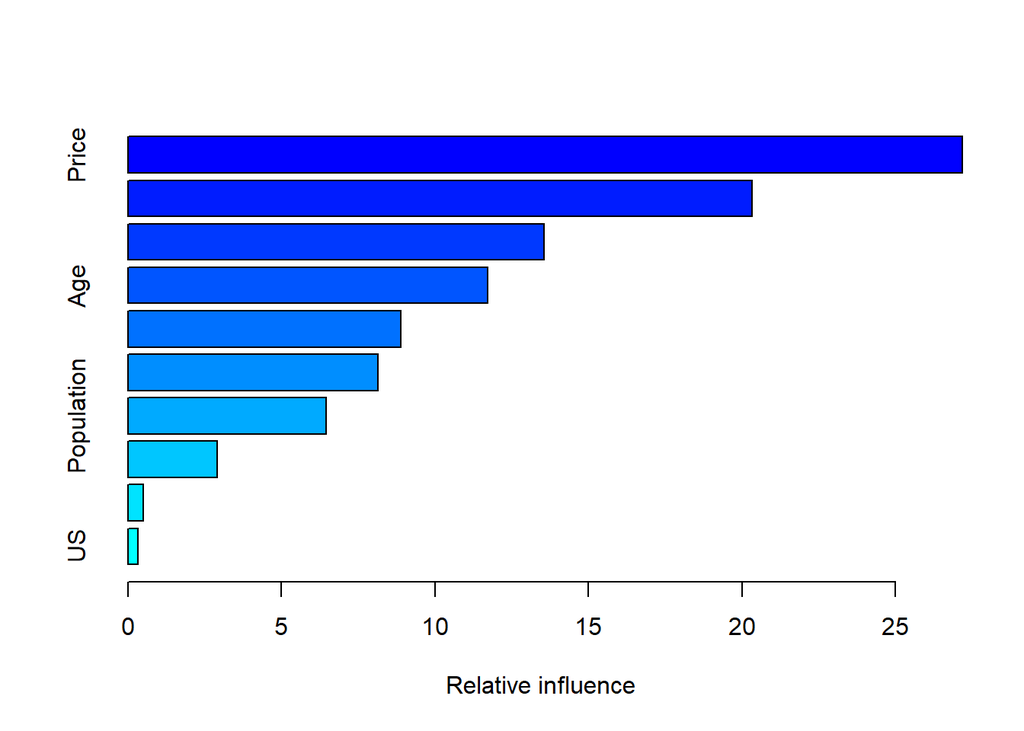

```
##                     var    rel.inf
## Price             Price 27.1689500
## ShelveLoc     ShelveLoc 20.3245386
## CompPrice     CompPrice 13.5501438
## Age                 Age 11.7090974
## Income           Income  8.8957540
## Advertising Advertising  8.1432552
## Population   Population  6.4602005
## Education     Education  2.9079727
## Urban             Urban  0.5031582
## US                   US  0.3369297
```

```r
set.seed (1)
boost.Carseats <- gbm(Sales ∼ ., data = Carseats[train , ],
                    distribution = "gaussian", n.trees = 5000,
                    interaction.depth = 4)
summary(boost.Carseats)
```

Analizamos el performance del modelo:

```r
yhat.boost <- predict(boost.Carseats ,
                      newdata = Carseats[-train , ], n.trees = 5000)
mean (( yhat.boost - Carseats.test)^2)
```

```
## [1] 1.806206
```

Respuesta: Al emplear boosting, que posee un proceso de aprendizaje continuo con árboles ligados, se observa que el MSE se reduce a 1.806206. Esto implica una mejora en la capacidad predictiva del modelo que emplea Boosting por sobre Random Forests y Bagging.

Asimismo, se observa que las variables Price (precio) y Sherveloc (la calidad de la ubicación de las estanterías) son las más importantes del modelo.